# Advanced data management

Jing Fang

# This lecture covers

- Mathematical and statistical functions
- Character functions
- Looping and conditional execution
- User-written functions
- Ways to aggregate and reshape data.

# 5.1 A data management challenge

# A data management challenge

- Let’s consider a data management problem.
- A group of students have taken exams in Math, Science, and English.
- You want to combine these scores in order to determine a single performance indicator for each student.
- Additionally, you want to assign an A to the top 20% of student, a B to the next 20%, and so on.
- Finally, you want to sort the students alphabetically.

# A data management challenge

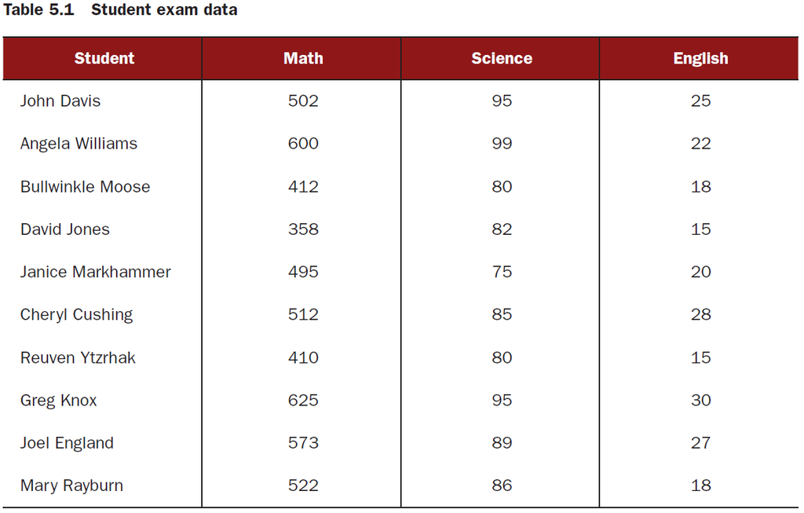

# 5.2 Numerical and character functions

# Numerical and character functions

- Looking at the this dataset, several obstacles are immediately evident.
  - First, scores on the three exams aren’t comparable.
  - Second, you’ll need a method of determining a student’s percentile rank on this score in order to assign a grade.
  - Third, there’s a single field for names, complicating the task of sorting students.
- Each of these tasks can be accomplished through the judicious use of R’s numerical and character functions.

# Numerical and character functions

- We’ll review functions in R that can be used as the basic building blocks for manipulating data.
- numerical
  - mathematical
  - statistical
  - probability
- character

# Mathematical functions

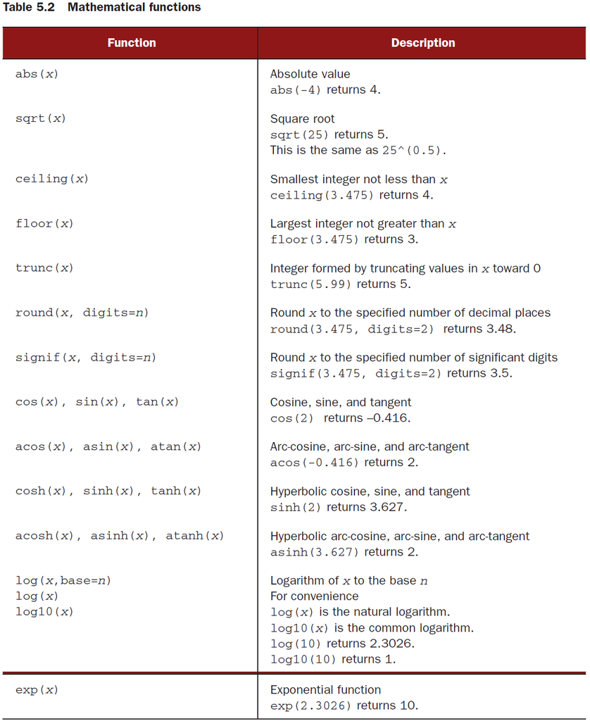

# Statistical functions

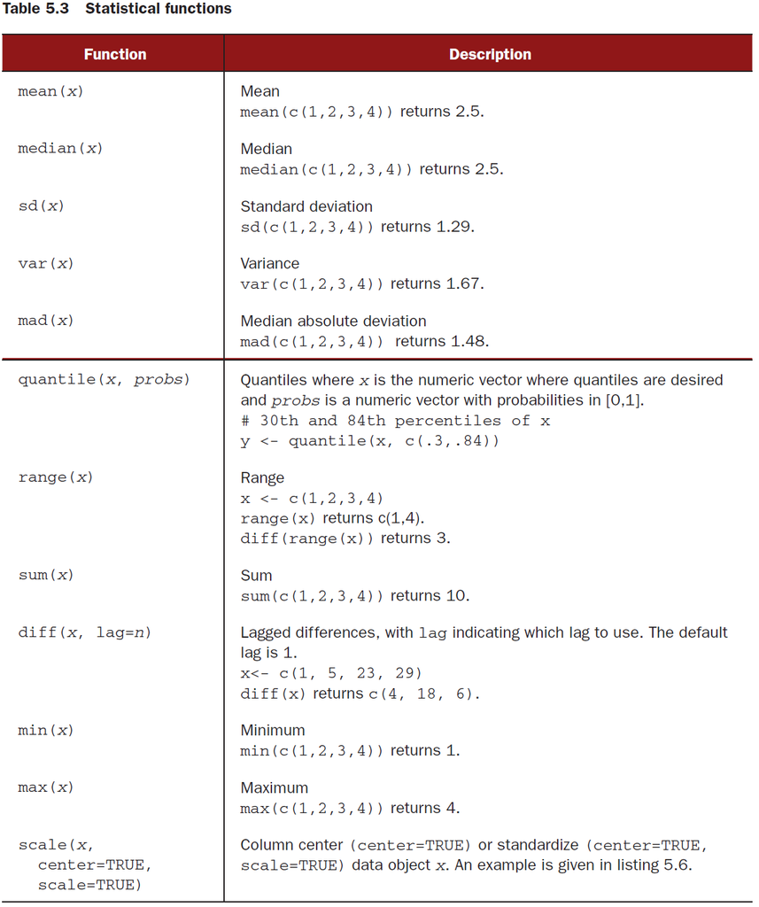

# Statistical functions

```r
x <- 1:8
mean(x)
sd(x)

n <- length(x)
mean2 <- sum(x)/n
css <- sum((x - mean2)^2)
sd2 <- sqrt(css/(n - 1))
mean2
sd2
```

# Statistical functions

```r
x <- 1:8
mean(x)
```

```
## [1] 4.5
```

```r
sd(x)
```

```
## [1] 2.449
```

```r
n <- length(x)
mean2 <- sum(x)/n
css <- sum((x - mean2)^2)
sd2 <- sqrt(css/(n - 1))
mean2
```

```
## [1] 4.5
```

```r
sd2
```

```
## [1] 2.449
```

# Statistical functions

- By default, the `scale()` function standardizes the specified columns of a matrix or data frame to a mean of 0 and a standard deviation of 1

  ```r
  newdata <- scale(mydata)
  ```

# Probability functions

- In R, probability functions take the form: `[dpqr]distribution_abbreviation()`
- Where the first letter refers to the aspect of the distribution returned:
  - d = density
  - p = distribution function
  - q = quantile function
  - r = random generation

# Probability functions

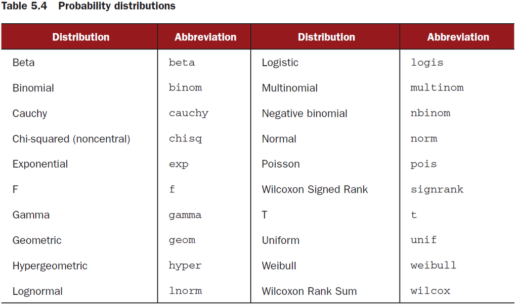

# Probability functions

- Plot the standard normal curve on the interval [-3,3]

```r
library(ggplot2)
x <- pretty(c(-3, 3), 30)
y <- dnorm(x)
qplot(x, y, geom = "line", xlab = "Normal Deviate", ylab = "Density")
```

# Probability functions

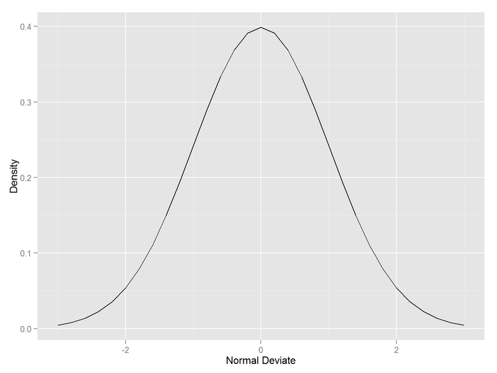

# Probability functions

- What is the area under the curve to the left of z=1.96?

  ```r
  pnorm(1.96)
  ```

  ```
  ## [1] 0.975
  ```

- What is the value of the 90th percentile of a normal distribution with a mean 500 and a standard deviation of 100?

  ```r
  qnorm(0.9, mean = 500, sd = 100)
  ```

  ```
  ## [1] 628.2
  ```

- Generate 50 random normal deviates with a mean of 50 and a standard deviation of 10.

  ```r
  rnorm(50, mean = 50, sd = 10)
  ```

  ```
  ##  [1] 61.43 63.07 46.04 62.48 43.86 50.27 48.22 59.78 47.92 29.33 48.79
  ## [12] 37.73 48.31 61.23 50.51 63.59 50.40 54.26 45.11 52.93 41.01 45.44
  ## [23] 42.82 66.75 41.83 45.87 49.31 50.17 56.03 55.72 47.58 50.57 51.16
  ## [34] 30.14 50.67 51.78 37.19 43.11 54.62 38.92 46.01 45.09 46.56 48.11
  ## [45] 37.35 47.86 54.76 69.69 39.62 55.78
  ```

# Probability functions

- Each time you generate pseudo-random deviates, a different seed, and therefore different results, are produced.
- To make your results reproducible, you can specify the seed explicitly, using the `set.seed()` function.

  ```r
  runif(5)
  ```

  ```
  ## [1] 0.6217 0.1907 0.2244 0.8249 0.4267
  ```

  ```r
  runif(5)
  ```

  ```
  ## [1] 0.02174 0.91551 0.46634 0.84478 0.11344
  ```

  ```r
  set.seed(1234)
  runif(5)
  ```

  ```
  ## [1] 0.1137 0.6223 0.6093 0.6234 0.8609
  ```

  ```r
  set.seed(1234)
  runif(5)
  ```

  ```
  ## [1] 0.1137 0.6223 0.6093 0.6234 0.8609
  ```

# Character functions

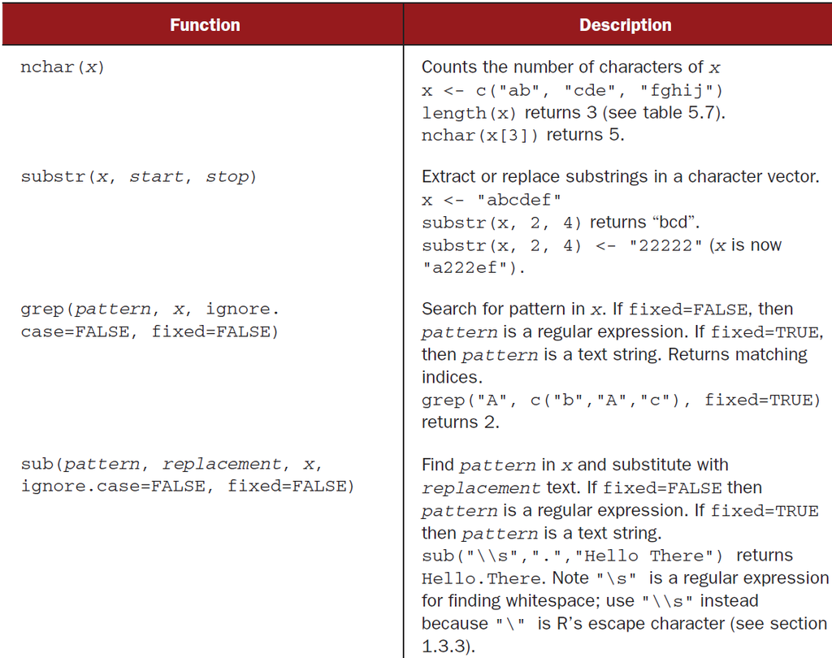

# Character functions

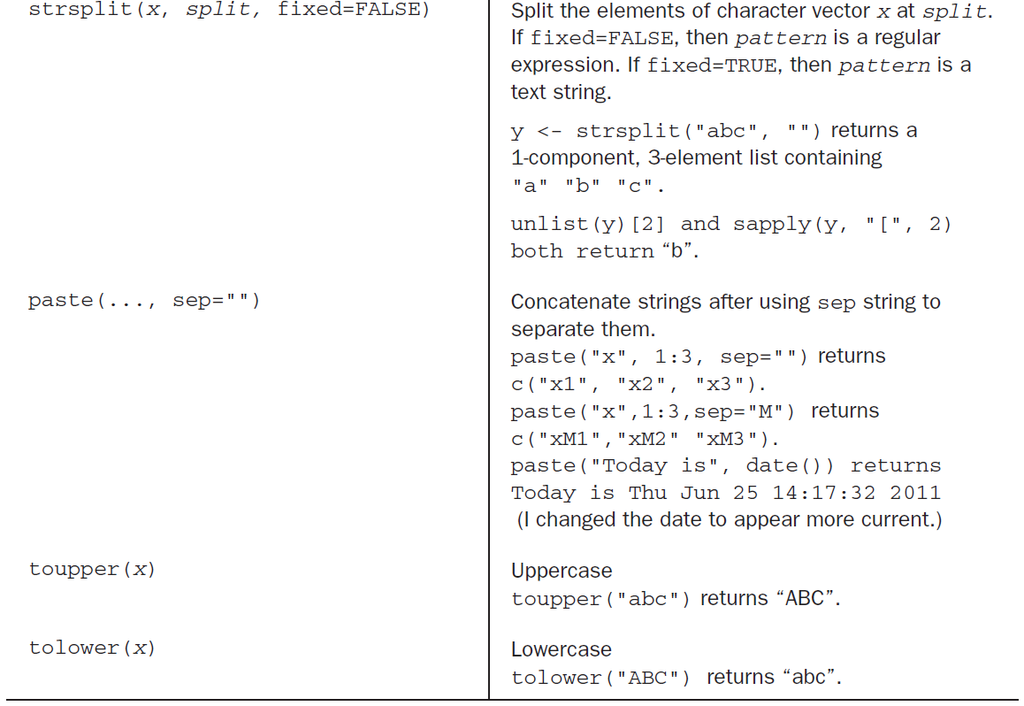

# Character functions

- Here I also want to introduce a package for character: `stringr`
- `stringr` is a set of simple wrappers that make R’s string functions more consistent, simpler and easier to use.
- It does this by ensuring that: function and argument names (and positions) are consistent, all functions deal with NA’s and zero length character appropriately, and the output data structures from each function matches the input data structures of other functions.
- Next we’ll introduce some counterpart functions for previous one.

# Character functions

| Stringr | Base |
| --- | --- |
| fixed(x) | fixed=FALSE |
| ignore.case(x) | ignore.case=FALSE |
| str_length(x) | nchar(x) |
| str_sub(x, start, end) | substr(x, start, stop) |
| str_locate(x, pattern) | grep(pattern, x) |
| str_replace(x, pattern, replacement) | sub(pattern, replacement, x) |
| str_split(x, pattern, n=Inf) | strsplit(x, split) |
| str_c(x, sep=””, collapse=NULL) | paste(…, sep=” ”) |

# Other useful functions

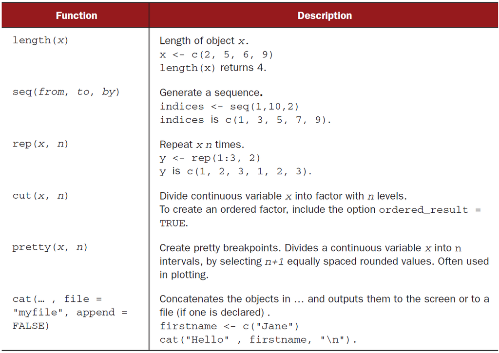

# Applying functions to matrices and data frames

- One of the interesting features of R functions is that they can applied to a variety of data object.

```r
a = 5
sqrt(a)
```

```
## [1] 2.236
```

```r
b = c(1.243, 5.654, 2.99)
round(b)
```

```
## [1] 1 6 3
```

```r
c = matrix(runif(12), nrow = 3)
c
```

```
##          [,1]   [,2]   [,3]   [,4]
## [1,] 0.640311 0.6661 0.5450 0.2923
## [2,] 0.009496 0.5143 0.2827 0.8373
## [3,] 0.232551 0.6936 0.9234 0.2862
```

# Applying functions to matrices and data frames

```r
log(c)
```

```
##         [,1]    [,2]     [,3]    [,4]
## [1,] -0.4458 -0.4063 -0.60702 -1.2299
## [2,] -4.6569 -0.6650 -1.26325 -0.1776
## [3,] -1.4586 -0.3659 -0.07966 -1.2510
```

```r
mean(c)
```

```
## [1] 0.4936
```

- Notice that the `mean()` function took the average of all 12 elements in the matrix.
- What if you wanted to 3 row means or the 4 column means?

# Applying functions to matrices and data frames

- R provides a function, `apply()`, that allow you to apply an arbitrary function to any dimension of a matrix, array, or data frame.
- The format for the apply function is `apply(x, MARGIN, FUN,...)`

  ```r
  mydata <- matrix(rnorm(30), nrow = 6)
  mydata
  apply(mydata, 1, mean)
  apply(mydata, 2, mean)
  apply(mydata, 2, mean, trim = 0.2)
  ```

# Applying functions to matrices and data frames

```r
mydata <- matrix(rnorm(30), nrow = 6)
mydata
```

```
##         [,1]     [,2]      [,3]     [,4]    [,5]
## [1,] -0.6225 -1.68733  0.375636  0.01140 0.54317
## [2,] -0.7315 -0.62744  0.310262  0.00986 0.02143
## [3,] -0.5167  0.01832  0.005007  0.67827 0.16257
## [4,] -1.7507  0.70524 -0.037630  1.02956 1.24175
## [5,]  0.8801 -0.64702  0.723976 -1.72953 0.78278
## [6,]  1.3700  0.86818 -0.496739 -2.20435 0.04812
```

```r
apply(mydata, 1, mean)
```

```
## [1] -0.275916 -0.203485  0.069498  0.237639  0.002062 -0.082955
```

```r
apply(mydata, 2, mean)
```

```
## [1] -0.2285 -0.2283  0.1468 -0.3675  0.4666
```

```r
apply(mydata, 2, mean, trim = 0.2)
```

```
## [1] -0.2476 -0.1377  0.1633 -0.2575  0.3842
```

# Applying functions to matrices and data frames

- In the last case, means based on the middle 60% of the data, with the bottom 20% and top 20% of values discard.
- Because `FUN` can be any R function, including a function that you write yourself, `apply()` is a powerful mechanism.
- While `apply()` applies a function over the margin of an array, `lapply()` and `sapply()` apply a function over a list.
- You now have all the tools you need to solve the data challenge.

# 5.3 A solution for our data management challenge

# A solution for our data management challenge

- Your challenge is to combine subject test scores into a single performance indicator for each student, grade each student from A to F based on their relative standing, and sort the roster by students’ last name, followed by first name.
- The code will be dense, so let’s walk through the solution step by step:

# A solution for our data management challenge

- Step 1. The original student roster is given.

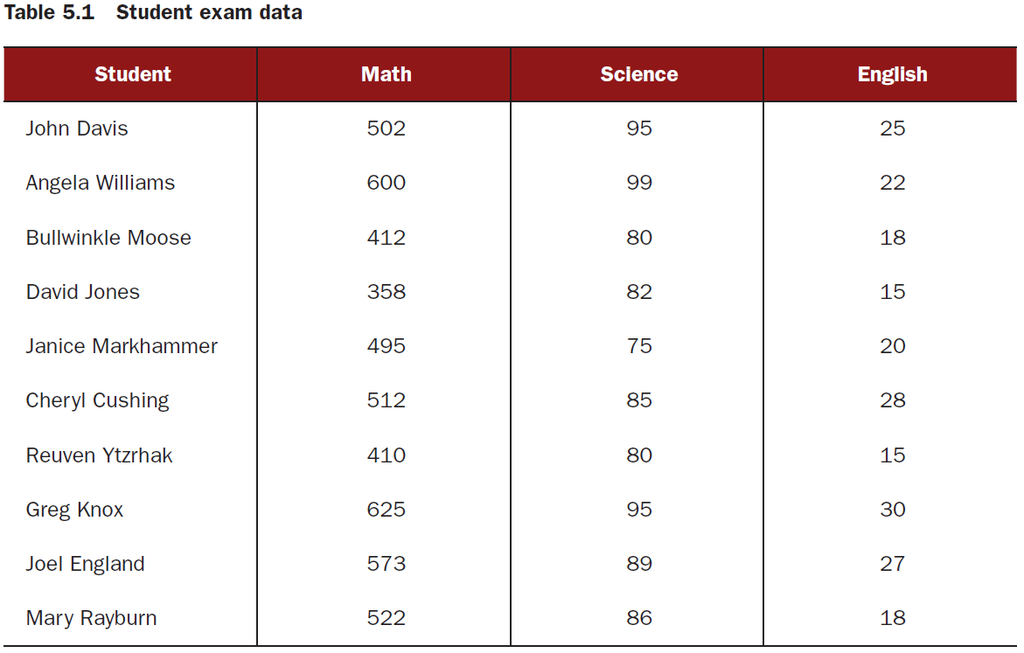

# A solution for our data management challenge

```r
options(digits = 2)
Student <- c("John Davis", "Angela Williams", "Bullwinkle Moose", "David Jones",
    "Janice Markhammer", "Cheryl Cushing", "Reuven Ytzrhak", "Greg Knox", "Joel England",
    "Mary Rayburn")
Math <- c(502, 600, 412, 358, 495, 512, 410, 625, 573, 522)
Science <- c(95, 99, 80, 82, 75, 85, 80, 95, 89, 86)
English <- c(25, 22, 18, 15, 20, 28, 15, 30, 27, 18)
roster <- data.frame(Student, Math, Science, English, stringsAsFactors = FALSE)
roster
```

```
##              Student Math Science English
## 1         John Davis  502      95      25
## 2    Angela Williams  600      99      22
## 3   Bullwinkle Moose  412      80      18
## 4        David Jones  358      82      15
## 5  Janice Markhammer  495      75      20
## 6     Cheryl Cushing  512      85      28
## 7     Reuven Ytzrhak  410      80      15
## 8          Greg Knox  625      95      30
## 9       Joel England  573      89      27
## 10      Mary Rayburn  522      86      18
```

# A solution for our data management challenge

- Step 2. Because the Math, Science, and English tests are reported on different scales, you need to make them comparable before combining them.

  ```r
  z <- scale(roster[, 2:4])
  z
  ```

  ```
  ##         Math Science English
  ##  [1,]  0.013   1.078   0.587
  ##  [2,]  1.143   1.591   0.037
  ##  [3,] -1.026  -0.847  -0.697
  ##  [4,] -1.649  -0.590  -1.247
  ##  [5,] -0.068  -1.489  -0.330
  ##  [6,]  0.128  -0.205   1.137
  ##  [7,] -1.049  -0.847  -1.247
  ##  [8,]  1.432   1.078   1.504
  ##  [9,]  0.832   0.308   0.954
  ## [10,]  0.243  -0.077  -0.697
  ## attr(,"scaled:center")
  ##    Math Science English
  ##     501      87      22
  ## attr(,"scaled:scale")
  ##    Math Science English
  ##    86.7     7.8     5.5
  ```

# A solution for our data management challenge

- Step 3. You can then get a performance score for each student by calculating the row means using the `mean()` function and adding it to the roster using the `cbind()` function:

  ```r
  score <- apply(z, 1, mean)
  roster <- cbind(roster, score)
  roster
  ```

  ```
  ##              Student Math Science English score
  ## 1         John Davis  502      95      25  0.56
  ## 2    Angela Williams  600      99      22  0.92
  ## 3   Bullwinkle Moose  412      80      18 -0.86
  ## 4        David Jones  358      82      15 -1.16
  ## 5  Janice Markhammer  495      75      20 -0.63
  ## 6     Cheryl Cushing  512      85      28  0.35
  ## 7     Reuven Ytzrhak  410      80      15 -1.05
  ## 8          Greg Knox  625      95      30  1.34
  ## 9       Joel England  573      89      27  0.70
  ## 10      Mary Rayburn  522      86      18 -0.18
  ```

# A solution for our data management challenge

- Step 4. The `quantile()` function gives you the percentile rank of each student’s performance score.

  ```r
  y <- quantile(roster$score, c(0.8, 0.6, 0.4, 0.2))
  y
  ```

  ```
  ##   80%   60%   40%   20%
  ##  0.74  0.44 -0.36 -0.89
  ```

# A solution for our data management challenge

- Step 5. Using logical operators, you can recode students’ percentile ranks into a new categorical grade variable.

  ```r
  roster$grade[score >= y[1]] <- "A"
  roster$grade[score < y[1] & score >= y[2]] <- "B"
  roster$grade[score < y[2] & score >= y[3]] <- "C"
  roster$grade[score < y[3] & score >= y[4]] <- "D"
  roster$grade[score < y[4]] <- "F"
  roster
  ```

  ```
  ##              Student Math Science English score grade
  ## 1         John Davis  502      95      25  0.56     B
  ## 2    Angela Williams  600      99      22  0.92     A
  ## 3   Bullwinkle Moose  412      80      18 -0.86     D
  ## 4        David Jones  358      82      15 -1.16     F
  ## 5  Janice Markhammer  495      75      20 -0.63     D
  ## 6     Cheryl Cushing  512      85      28  0.35     C
  ## 7     Reuven Ytzrhak  410      80      15 -1.05     F
  ## 8          Greg Knox  625      95      30  1.34     A
  ## 9       Joel England  573      89      27  0.70     B
  ## 10      Mary Rayburn  522      86      18 -0.18     C
  ```

# A solution for our data management challenge

- Step 6. You’ll use the `str_split()` function to break student names into first name and last name at the space character.

  ```r
  library(stringr)
  name <- str_split(roster$Student, " ")
  name
  ```

  ```
  ## [[1]]
  ## [1] "John"  "Davis"
  ##
  ## [[2]]
  ## [1] "Angela"   "Williams"
  ##
  ## [[3]]
  ## [1] "Bullwinkle" "Moose"
  ##
  ## [[4]]
  ## [1] "David" "Jones"
  ##
  ## [[5]]
  ## [1] "Janice"     "Markhammer"
  ##
  ## [[6]]
  ## [1] "Cheryl"  "Cushing"
  ##
  ## [[7]]
  ## [1] "Reuven"  "Ytzrhak"
  ##
  ## [[8]]
  ## [1] "Greg" "Knox"
  ##
  ## [[9]]
  ## [1] "Joel"    "England"
  ##
  ## [[10]]
  ## [1] "Mary"    "Rayburn"
  ```

# A solution for our data management challenge

- Step 7. You can use the `sapply()` function to take the first element of each component and put it in a firstname vector, and the second element of each component and put it in a lastname vector.

  ```r
  Firstname <- sapply(name, "[", 1)
  Lastname <- sapply(name, "[", 2)
  roster <- cbind(Firstname, Lastname, roster[, -1])
  roster
  ```

  ```
  ##     Firstname   Lastname Math Science English score grade
  ## 1        John      Davis  502      95      25  0.56     B
  ## 2      Angela   Williams  600      99      22  0.92     A
  ## 3  Bullwinkle      Moose  412      80      18 -0.86     D
  ## 4       David      Jones  358      82      15 -1.16     F
  ## 5      Janice Markhammer  495      75      20 -0.63     D
  ## 6      Cheryl    Cushing  512      85      28  0.35     C
  ## 7      Reuven    Ytzrhak  410      80      15 -1.05     F
  ## 8        Greg       Knox  625      95      30  1.34     A
  ## 9        Joel    England  573      89      27  0.70     B
  ## 10       Mary    Rayburn  522      86      18 -0.18     C
  ```

# A solution for our data management challenge

- Step 8. Finally, you can sort the dataset by first and last name using the `order()` function.

  ```r
  roster[order(Lastname, Firstname), ]
  ```

  ```
  ##     Firstname   Lastname Math Science English score grade
  ## 6      Cheryl    Cushing  512      85      28  0.35     C
  ## 1        John      Davis  502      95      25  0.56     B
  ## 9        Joel    England  573      89      27  0.70     B
  ## 4       David      Jones  358      82      15 -1.16     F
  ## 8        Greg       Knox  625      95      30  1.34     A
  ## 5      Janice Markhammer  495      75      20 -0.63     D
  ## 3  Bullwinkle      Moose  412      80      18 -0.86     D
  ## 10       Mary    Rayburn  522      86      18 -0.18     C
  ## 2      Angela   Williams  600      99      22  0.92     A
  ## 7      Reuven    Ytzrhak  410      80      15 -1.05     F
  ```

# 5.4 Control flow

# Control flow

- For the syntax examples throughout this section, keep the following in mind:
- `statement` is a single R statement or a compound statement.
  - `cond` is an expression that resolves to true or false.
  - `expr` is a statement that evaluates to a number or character string
  - `seq` is a sequence of numbers or character strings

# Repetition and looping

- Looping constructs repetitively execute a statement or series of statements until a condition isn’t true.
- The for loop executes a statement repetitively until a variable’s value is no longer contained in the sequence seq.
  - `for (var in seq) statement`
- A while loop executes a statement repetitively until the condition is no longer true.
  - `while (cond) statement`

# conditional execution

- In conditional execution, a statement or statements are only executed if a specified condition is met.
- The if-else control structure executes a statement if a given condition is true
  - `if (cond) statement`
  - `if (cond) statement1 else statement2`
- The ifelse construct is a compact and vectorized version of the if-else construct.
  - `ifelse(cond, statement1, statement2)`
- switch chooses statements based on the value of an expression.
  - `switch(expr,...)`

# conditional execution

```r
feelings = c("sad", "afraid")
for (i in feelings) {
    print(switch(i, happy = "I am glad you are happy", afraid = "There is nothing to fear",
        sad = "Cheer up", angry = "Calm down now"))
}
```

```
## [1] "Cheer up"
## [1] "There is nothing to fear"
```

# 5.5 User-written functions

# User-written functions

- One of R’s greatest strengths is the user’s ability to add functions.
- The structure of a function looks like this:
  - `myfunction <- function(arg1, arg2, ...){`
    - `statement`
    - `return(object)`
  - `}`

# User-written functions

```r
mystats <- function(x, parametric = TRUE, print = FALSE) {
    if (parametric) {
        center <- mean(x)
        spread <- sd(x)
    } else {
        center <- median(x)
        spread <- mad(x)  #median absolute deviation
    }
    if (print & parametric) {
        cat("Mean=", center, "\n", "SD=", spread, "\n")
    } else if (print & !parametric) {
        cat("Median=", center, "\n", "MAD=", spread, "\n")
    }
    result <- list(center = center, spread = spread)
    return(result)
}
set.seed(1234)
x <- rnorm(500)
y <- mystats(x)
y <- mystats(x, parametric = FALSE, print = TRUE)
```

```
## Median= -0.021
##  MAD= 1
```

# 5.6 Aggregation and restructuring

# Aggregation and restructuring

- R provides a number of powerful methods for aggregating and reshaping data.
- When you aggregate dat, you replace groups of observations with summary statistics based on those observations.
- When you reshape data, you alter the structure determining how the data is organized.

# Transpose

- Use the `t()` function to transpose a matrix or a data frame.

  ```r
  cars <- mtcars[1:5, 1:4]
  cars
  ```

  ```
  ##                   mpg cyl disp  hp
  ## Mazda RX4          21   6  160 110
  ## Mazda RX4 Wag      21   6  160 110
  ## Datsun 710         23   4  108  93
  ## Hornet 4 Drive     21   6  258 110
  ## Hornet Sportabout  19   8  360 175
  ```

  ```r
  t(cars)
  ```

  ```
  ##      Mazda RX4 Mazda RX4 Wag Datsun 710 Hornet 4 Drive Hornet Sportabout
  ## mpg         21            21         23             21                19
  ## cyl          6             6          4              6                 8
  ## disp       160           160        108            258               360
  ## hp         110           110         93            110               175
  ```

# Aggregating data

- It’s relatively easy to collapse data in R using one or more by variables and a defined function.
- The format is `aggregate(x, by, FUN)`, where
  - `x` is the data object to be collapsed,
  - `by` is a list of variable that will be crossed to form the new observation,
  - and `FUN` is the scalar function used to calculate summary statistics that will make up the new observation values.

# Aggregating data

```r
options(digits = 3)
aggdata <- aggregate(mtcars, by = list(mtcars$cyl, mtcars$gear), FUN = mean,
    na.rm = TRUE)
aggdata
```

```
##   Group.1 Group.2  mpg cyl disp  hp drat   wt qsec  vs   am gear carb
## 1       4       3 21.5   4  120  97 3.70 2.46 20.0 1.0 0.00    3 1.00
## 2       6       3 19.8   6  242 108 2.92 3.34 19.8 1.0 0.00    3 1.00
## 3       8       3 15.1   8  358 194 3.12 4.10 17.1 0.0 0.00    3 3.08
## 4       4       4 26.9   4  103  76 4.11 2.38 19.6 1.0 0.75    4 1.50
## 5       6       4 19.8   6  164 116 3.91 3.09 17.7 0.5 0.50    4 4.00
## 6       4       5 28.2   4  108 102 4.10 1.83 16.8 0.5 1.00    5 2.00
## 7       6       5 19.7   6  145 175 3.62 2.77 15.5 0.0 1.00    5 6.00
## 8       8       5 15.4   8  326 300 3.88 3.37 14.6 0.0 1.00    5 6.00
```

# The reshape2 package

- The `reshape2` package is a tremendously versatile approach to both restructuring and aggregating datasets.
- It lets you flexibly restructure and aggregate data using just two functions: `melt` and `cast`.
- Basically, you’ll `melt` data so that each row is a unique ID-variable combination.
- Then you’ll `cast` the melted data into any shape you desire.

# The reshape2 package

- The dataset we’ll be working with is:

  ```r
  ID = c(1, 1, 2, 2)
  Time = c(1, 2, 1, 2)
  X1 = c(5, 3, 6, 2)
  X2 = c(6, 5, 1, 4)
  mydata = data.frame(ID, Time, X1, X2)
  mydata
  ```

  ```
  ##   ID Time X1 X2
  ## 1  1    1  5  6
  ## 2  1    2  3  5
  ## 3  2    1  6  1
  ## 4  2    2  2  4
  ```

# The reshape2 package

- When you melt a dataset, you restructure it into a format where each measured variable is in its own row, along with the ID variables needed to uniquely identify it.

  ```r
  library(reshape2)
  md = melt(mydata, id = c("ID", "Time"))
  md
  ```

  ```
  ##   ID Time variable value
  ## 1  1    1       X1     5
  ## 2  1    2       X1     3
  ## 3  2    1       X1     6
  ## 4  2    2       X1     2
  ## 5  1    1       X2     6
  ## 6  1    2       X2     5
  ## 7  2    1       X2     1
  ## 8  2    2       X2     4
  ```

# The reshape2 package

- The `cast()` function starts with melted data and reshapes it using a formula that you provide and an (optional) function used to aggregate the data.
- The format is
  - `newdata <- cast(md, formula, FUN)`
- where `md` is the melted data, `formula` describes the desired end result, and `FUN` is the (optional) aggregating function.
- The formula takes the form:
  - `rowvar1 + rowvar2 + ... ~ colvar1 + colvar2 + ...`

# The reshape2 package

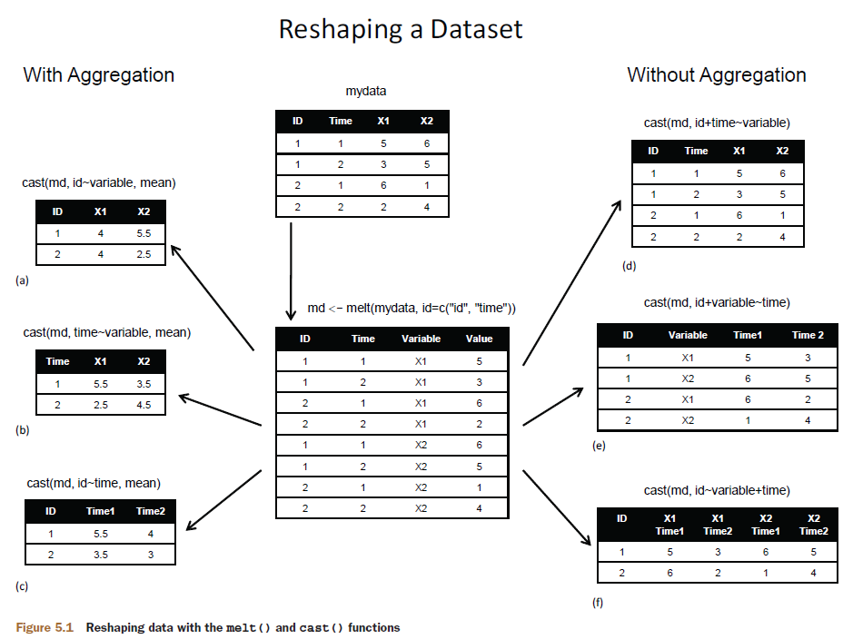